# Introduction to mirrorslope

## What a mirror slope plot shows

The mirrored slopegraph was designed by Kati Maharry and is described in Maharry and Sullivan (2026, manuscript in preparation). It was first used in the supplementary appendix of the HOPE-3 trial report (McDonald et al., *Lancet* 2026, doi:10.1016/S0140-6736(26)01385-1). This package implements the display.

The x-axis is positional, not numeric: it encodes baseline versus endpoint for each arm and should not be read as elapsed time.

Because `mirror_slope_plot()` returns a standard `ggplot` object, the full ggplot2 ecosystem remains available for further customisation.

## The pipeline

A plot is built in stages. Each stage returns a `mirror_data` object, so the steps compose naturally with the pipe. The object stores everything available; the plot call exposes only what is requested.

1. `prep_mirror_data()` validates and structures the analysis data.
2. `add_summary()` attaches the group-level estimates that define the mean lines.
3. `add_precision()` optionally attaches per-arm standard errors or intervals.
4. `add_difference()` optionally attaches the between-arm difference and its precision and p-value.
5. `mirror_slope_plot()` renders the figure.

## A minimal example

We simulate a small change-from-baseline dataset with two arms and two visits.

```r
set.seed(1)
n <- 40
df <- data.frame(
  USUBJID = rep(paste0("S", seq_len(n)), each = 2),
  TRTP    = rep(c(rep("Placebo", n / 2), rep("Active", n / 2)), each = 2),
  AVISIT  = rep(c("Baseline", "Week 24"), times = n),
  AVAL    = c(rbind(rep(0, n),
                    c(rnorm(n / 2, -10, 5), rnorm(n / 2, -6, 5)))),
  stringsAsFactors = FALSE
)
head(df, 4)
```

```
#>   USUBJID    TRTP   AVISIT       AVAL
#> 1      S1 Placebo Baseline   0.000000
#> 2      S1 Placebo  Week 24 -13.132269
#> 3      S2 Placebo Baseline   0.000000
#> 4      S2 Placebo  Week 24  -9.081783
```

Prepare the data and attach the summary estimates:

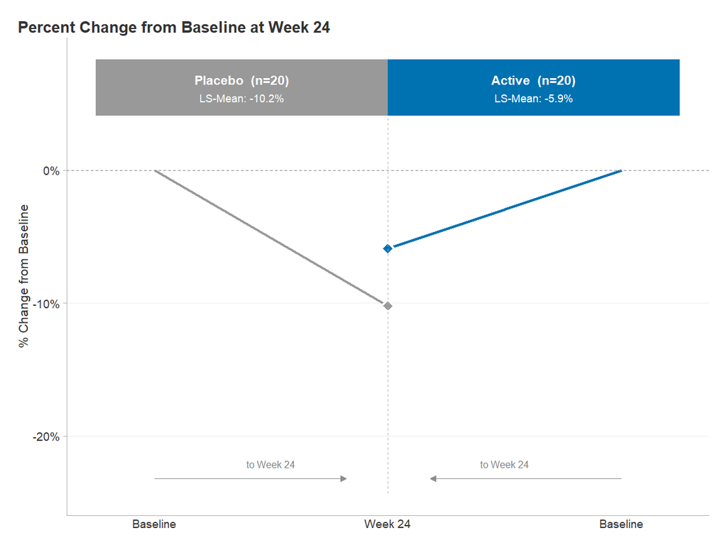

```r
md <- prep_mirror_data(
  df,
  trt_levels    = c("Placebo", "Active"),
  time_baseline = "Baseline",
  time_endpoint = "Week 24",
  value_label   = "% Change from Baseline"
)

md <- add_summary(
  md,
  estimates  = c("Placebo" = -10.2, "Active" = -5.9),
  stat_label = "LS-Mean"
)

mirror_slope_plot(
  md,
  trt_colors = mirror_palette("colorblind"),
  title      = "Percent Change from Baseline at Week 24"
)
```

## Adding the difference and relative benefit

Attaching a difference enables the annotation zone to the right of the panel. `show_difference` displays the difference value; `show_slowing` adds the derived relative benefit. Either one also draws the shaded band between the two means.

[output not shown]

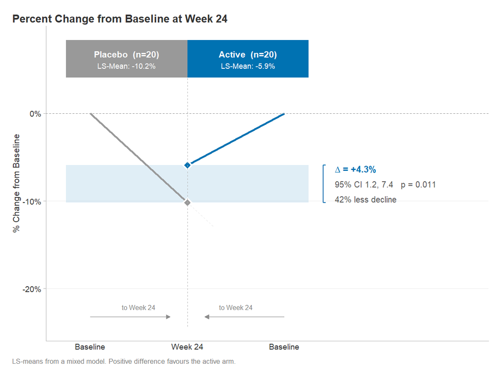

```r
md <- add_difference(
  md,
  estimate = 4.3,
  ci_lower = 1.2,
  ci_upper = 7.4,
  p_value  = 0.011
)

mirror_slope_plot(
  md,
  trt_colors      = mirror_palette("colorblind"),
  show_difference = TRUE,
  show_slowing    = TRUE,
  title           = "Percent Change from Baseline at Week 24",
  footnote        = "LS-means from a mixed model. Positive difference favours the active arm."
)
```

## Showing per-arm precision

`add_precision()` stores standard errors or confidence intervals per arm. Setting `show_precision = TRUE` draws a precision bar at each endpoint marker.

[output not shown]

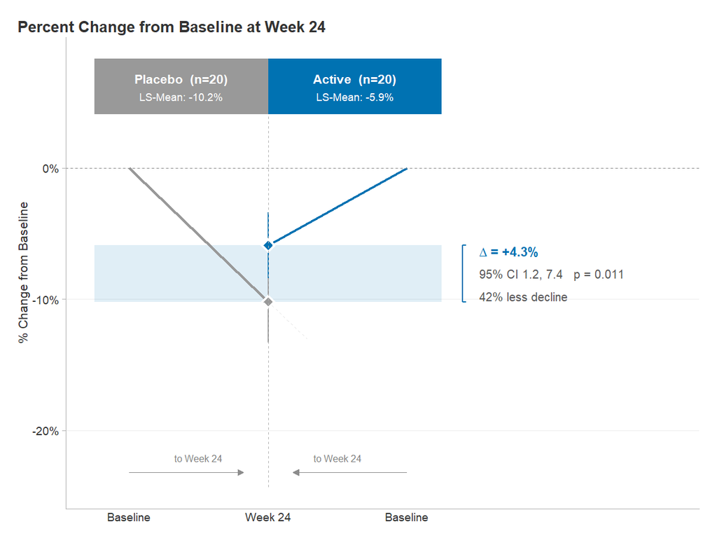

```r
md <- add_precision(
  md,
  ci = list("Placebo" = c(-13.3, -7.1),
            "Active"  = c(-8.4, -3.4))
)

mirror_slope_plot(
  md,
  trt_colors      = mirror_palette("colorblind"),
  show_difference = TRUE,
  show_slowing    = TRUE,
  show_precision  = TRUE,
  title           = "Percent Change from Baseline at Week 24"
)
```

## Individual subject trajectories

`show_spaghetti = TRUE` overlays each subject’s baseline-to-endpoint line beneath the group means. For large samples, reduce `spaghetti_alpha` to control overplotting.

[output not shown]

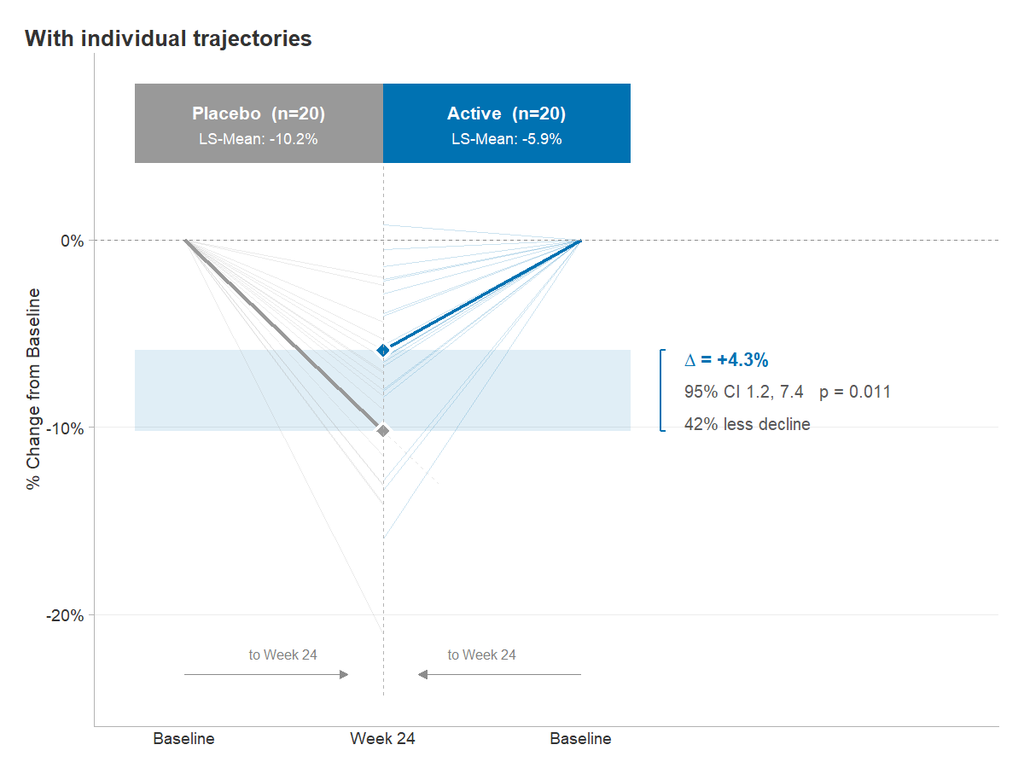

```r
mirror_slope_plot(
  md,
  trt_colors      = mirror_palette("colorblind"),
  show_spaghetti  = TRUE,
  spaghetti_alpha = 0.2,
  show_difference = TRUE,
  show_slowing    = TRUE,
  title           = "With individual trajectories"
)
```

## Inspecting the object

Printing a `mirror_data` object summarises the arms, analysed N, statistic label, and which optional elements are attached. `summary()` returns per-arm, per-timepoint descriptives.

```r
md
```

```
#> <mirror_data> schema 1.0
#>   Reference (left)  : Placebo  (n=20)
#>   Comparator (right): Active  (n=20)
#>   Timepoints        : Baseline  ->  Week 24
#>   Observations      : 80 OBS rows
#>   Summary           : yes (LS-Mean)
#>   Precision         : yes
#>   Difference        : yes
```

```r
summary(md)
```

```
#>       ARM TIMEROLE  N      MEAN       MIN        MAX
#> 1  Active BASELINE 20  0.000000   0.00000  0.0000000
#> 2 Placebo BASELINE 20  0.000000   0.00000  0.0000000
#> 3  Active ENDPOINT 20 -6.032358 -15.94676  0.7933978
#> 4 Placebo ENDPOINT 20 -9.047381 -21.07350 -2.0235960
```

## Next steps

See the *Clinical workflow with ADaM data* vignette for a realistic data-preparation pattern, and the *Customising the plot* vignette for theming, palettes, and combining multiple panels.